# Indicadores socioeconómicos y demográficos- Gapminder

2026-09-02

## Objetivos

**Objetivo principal**

Analizar la evolución y la relación entre diferentes indicadores socioeconómicos y demográficos a nivel mundial durante el periodo 1990–2019, utilizando datos de Gapminder.

**Objetivos específicos**

- Analizar la evolución temporal de los indicadores.
- Estudiar la relación entre PIB per cápita y esperanza de vida.
- Analizar la relación entre fertilidad y esperanza de vida.
- Estudiar la relación entre PIB per cápita y fertilidad.
- Comparar los indicadores entre diferentes territorios.

## Datos y metodología

- Datos procedentes de **Gapminder**.
- Se partió de **4 bases de datos**, correspondientes a los indicadores seleccionados.
- Las bases se **integraron y depuraron** para obtener un único conjunto de datos.
- El conjunto final contiene 193 territorios y abarca de 1990 a 2019.
- Se realizó un **análisis exploratorio (EDA)** para estudiar las distribuciones, evolución y relaciones entre variables.
- A partir del EDA se desarrolló un **dashboard interactivo** para explorar los resultados.

## Tabla resumen

| Indicador | Media |
| --- | --- |
| PIB per cápita | 25,261 |
| Esperanza de vida (años) | 73 |
| Población | 40.3 M |
| Hijos por mujer | 2.64 |

Los valores corresponden a la **media de los territorios en 2019**.

## Evolución temporal

Se analiza la evolución de los cuatro indicadores principales entre 1990 y 2019.

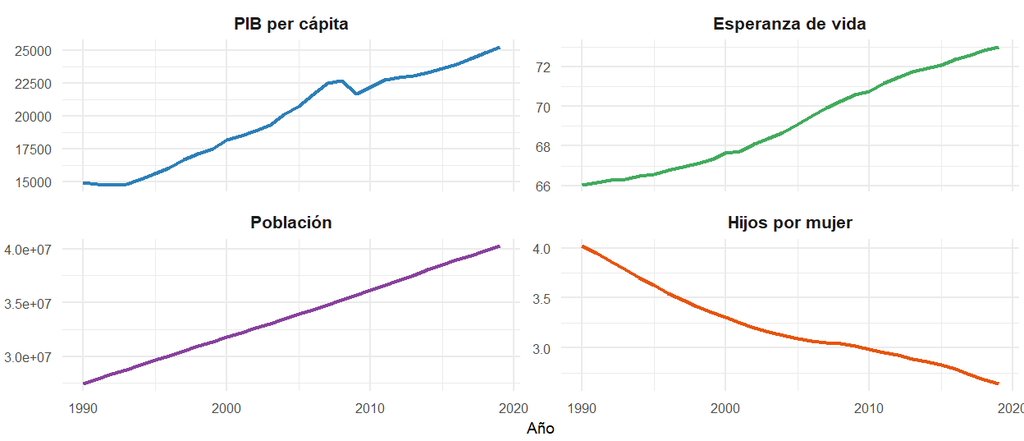

- **PIB per cápita, esperanza de vida y población:** tendencia creciente.
- **Hijos por mujer:** tendencia decreciente.

## Relación entre indicadores

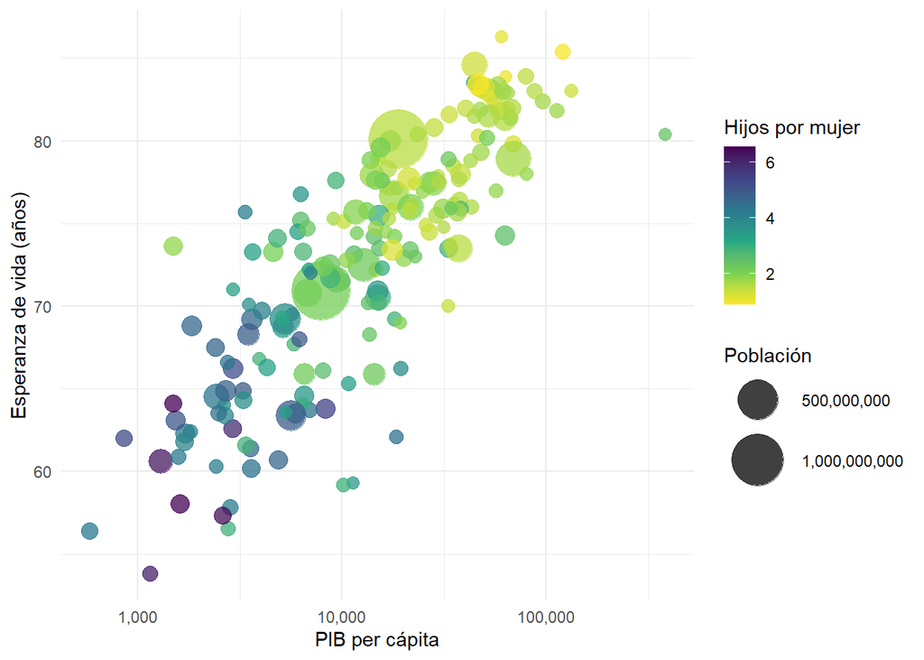

## Conclusiones

- Entre 1990 y 2019, el **PIB per cápita**, la **esperanza de vida** y la **población** aumentan.
- El número de **hijos por mujer disminuye** durante el periodo.
- En 2019 se observa una **relación positiva entre PIB per cápita y esperanza de vida**.
- Los territorios con menor PIB y esperanza de vida presentan, en general, **mayores niveles de fertilidad**.

El **dashboard interactivo** permite profundizar en estos resultados y comparar los indicadores entre diferentes años y territorios.